# Group_Assignment_2

Rahul Jadhav

2/7/2022

## Data Preparation

```r
main_dataset <- read.csv('Chicago_Crimes_2001_to_2017_Part2.csv')

## Assuming homicide, Assault, robbery, and sexual offense should be the categories for violent crimes. Let's put these columns together in a group.
unique(main_dataset$Primary.Type)
```

```
##  [1] "THEFT"                             "CRIM SEXUAL ASSAULT"
##  [3] "DECEPTIVE PRACTICE"                "BATTERY"
##  [5] "OTHER OFFENSE"                     "OFFENSE INVOLVING CHILDREN"
##  [7] "MOTOR VEHICLE THEFT"               "SEX OFFENSE"
##  [9] "NARCOTICS"                         "GAMBLING"
## [11] "PROSTITUTION"                      "WEAPONS VIOLATION"
## [13] "BURGLARY"                          "CRIMINAL DAMAGE"
## [15] "ASSAULT"                           "INTERFERENCE WITH PUBLIC OFFICER"
## [17] "CRIMINAL TRESPASS"                 "HOMICIDE"
## [19] "ROBBERY"                           "ARSON"
## [21] "PUBLIC PEACE VIOLATION"            "LIQUOR LAW VIOLATION"
## [23] "KIDNAPPING"                        "INTIMIDATION"
## [25] "STALKING"                          "OBSCENITY"
## [27] "PUBLIC INDECENCY"                  "RITUALISM"
## [29] "OTHER NARCOTIC VIOLATION"          "DOMESTIC VIOLENCE"
## [31] "NON-CRIMINAL"                      "CONCEALED CARRY LICENSE VIOLATION"
## [33] "HUMAN TRAFFICKING"                 "NON-CRIMINAL (SUBJECT SPECIFIED)"
## [35] "NON - CRIMINAL"
```

```r
cleaned_dataset <- main_dataset %>%
  mutate(
    Primary.Type = ifelse(Primary.Type=="HOMICIDE","HOMICIDE",
                          ifelse(Primary.Type=="CRIM SEXUAL ASSAULT" |
                                   Primary.Type=="SEX OFFENSE" , "SEXUAL OFFENCE",
                                 ifelse(Primary.Type == "ASSAULT","ASSAULT",
                                        ifelse(Primary.Type == "ROBBERY", "ROBBERY","Other"
                                               )
                                        )
                                 )
                          )
  )

cleaned_dataset <- filter(cleaned_dataset,cleaned_dataset$Primary.Type=="SEXUAL OFFENCE" |
                            cleaned_dataset$Primary.Type=="ASSAULT" |
                            cleaned_dataset$Primary.Type=="HOMICIDE" |
                            cleaned_dataset$Primary.Type=="ROBBERY" )




cleaned_dataset <- cleaned_dataset %>%
  select(Date,Block,Primary.Type,Location.Description,Arrest,Domestic,District,Ward,Year,Parts)

sapply(cleaned_dataset, function(x) sum(is.na(x)))
```

```
##                 Date                Block         Primary.Type
##                    0                    0                    0
## Location.Description               Arrest             Domestic
##                    0                    0                    0
##             District                 Ward                 Year
##                    5                25782                    0
##                Parts
##                    0
```

```r
## convertion of few variables and data variable class from character to POSIXct (data-time)
## Since arrest column had unique values as True, TRUE, False and FALSE. Replaced True with TRUE and False with FALSE

cleaned_dataset <- cleaned_dataset %>%
  mutate(
    Arrest = ifelse(
      Arrest == "False", "FALSE",
      ifelse(
        Arrest == "True", "TRUE", cleaned_dataset$Arrest
      )),
    Domestic = ifelse(
      Domestic == "False", "FALSE",
      ifelse(
        Domestic == "True", "TRUE", cleaned_dataset$Domestic
      )),
    Date = as.POSIXlt(Date, format = "%m/%d/%Y %I:%M:%S %p")
    )

cleaned_dataset <- cleaned_dataset %>%
  mutate(
    Month = format(cleaned_dataset$Date, format="%m"),
    Day = format(cleaned_dataset$Date, format="%d"),
    Time = format(cleaned_dataset$Date, format="%H")) %>%
  select(-Date)

## converting all Qualitative data to factorial Data
cleaned_dataset[sapply(cleaned_dataset, is.character)] <- lapply(
  cleaned_dataset[sapply(
    cleaned_dataset,
    is.character)]
  ,as.factor)
```

## SUMMARY STATISTIC

For numerical variable, we have created subset of numerical variable and categorical variable.

```r
## Summary Statistic of Continuous variables
psych::describe(cleaned_dataset) %>%
  dplyr::select(count = n,
         Mean = mean,
         Standard_Deviation = sd,
         )%>%
  mutate(
    Coefficient_Variation = Standard_Deviation/Mean
  )%>% na.omit()
```

```
##                        count     Mean Standard_Deviation Coefficient_Variation
## Block*                282629 18136.84           10445.91                  0.58
## Primary.Type*         282629     1.93               1.09                  0.57
## Location.Description* 282629   111.16              43.50                  0.39
## Arrest*               282629     1.19               0.39                  0.33
## Domestic*             282629     1.14               0.34                  0.30
## District              282624    10.76               6.88                  0.64
## Ward                  256847    21.21              13.26                  0.63
## Year                  282629  2007.71               4.16                  0.00
## Parts*                282629     1.00               0.00                  0.00
## Month*                282629     6.54               3.31                  0.51
## Day*                  282629    15.62               8.83                  0.57
## Time*                 282629    14.30               6.73                  0.47
```

```r
## Summary Statistic of Quantiative Variables
summary(cleaned_dataset[sapply(cleaned_dataset , is.factor)])
```

```
##                                  Block                Primary.Type
##  063XX S DR MARTIN LUTHER KING JR DR:   241   ASSAULT       :160143
##  0000X W WASHINGTON ST              :   225   HOMICIDE      :  3029
##  064XX S DR MARTIN LUTHER KING JR DR:   220   ROBBERY       : 99963
##  100XX W OHARE ST                   :   218   SEXUAL OFFENCE: 19494
##  112XX S WALLACE ST                 :   210
##  0000X W 95TH ST                    :   196
##  (Other)                            :281319
##                Location.Description   Arrest        Domestic
##  STREET                  :66255     FALSE:228887   FALSE:244457
##  SIDEWALK                :55221     TRUE : 53742   TRUE : 38172
##  RESIDENCE               :34884
##  APARTMENT               :25544
##  ALLEY                   :12083
##  SCHOOL, PUBLIC, BUILDING:10928
##  (Other)                 :77714
##    Parts            Month             Day              Time
##  Part2:282629   05     : 26707   01     : 10945   15     : 16674
##                 07     : 26622   15     :  9574   19     : 16062
##                 08     : 26168   14     :  9554   21     : 16015
##                 06     : 26115   16     :  9423   20     : 15995
##                 09     : 25061   20     :  9368   16     : 15870
##                 10     : 24843   10     :  9346   18     : 15864
##                 (Other):127113   (Other):224419   (Other):186149
```

## BASIC ANALYSIS

### Primary type of crimes

```r
group_by_primary_type <- cleaned_dataset %>%
  group_by(Primary.Type,Domestic) %>%
  summarise(count = n())%>%
  mutate(
    porportion = round(count/sum(count),2),
    percentage = round((count/sum(count)*100),2)
  ) %>%
  arrange(desc(percentage))
```

[figure not shown]

```r
ggplot(group_by_primary_type,aes(x=Primary.Type,y=count,fill=Domestic))+
  geom_bar(position="dodge", stat="identity")+
  theme(axis.text.x = element_text(angle = 90, vjust = 0.5, hjust=1))+
  scale_y_continuous(label = comma)+
  ggtitle("Bar Plot : 01 Top 10 crimes reported in Chicago with Domestic Violence")
```

```r
group_by_primary_type <- cleaned_dataset %>%
  group_by(Primary.Type,Arrest) %>%
  summarise(count = n())%>%
  mutate(
    porportion = round(count/sum(count),2),
    percentage = round((count/sum(count)*100),2)
  ) %>%
  arrange(desc(percentage))
```

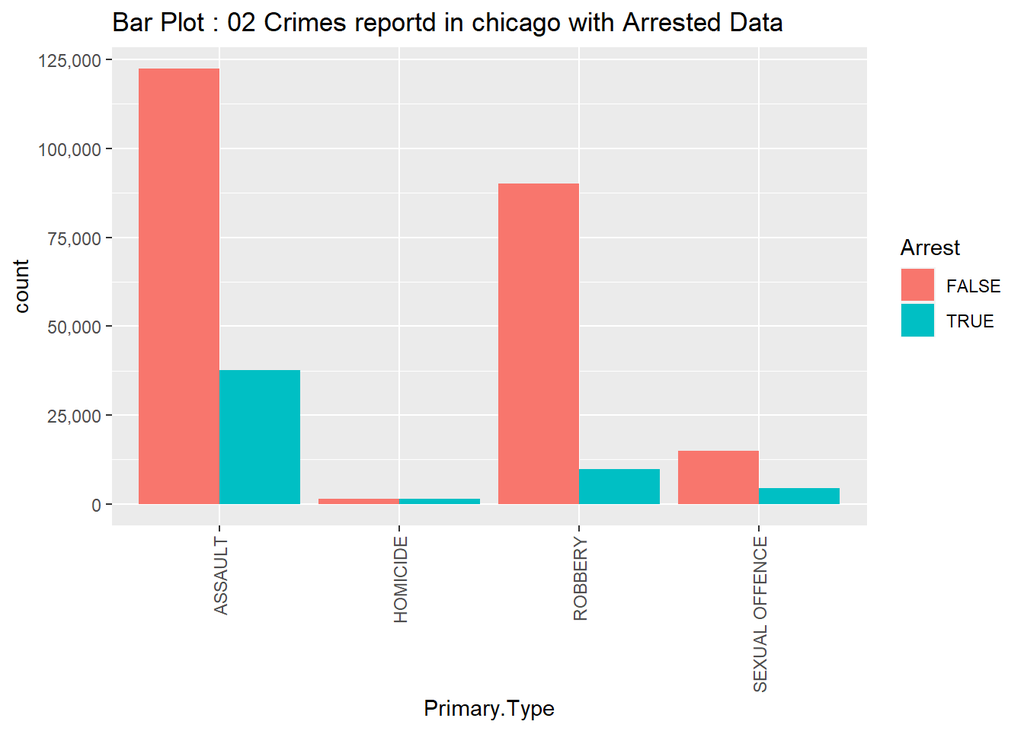

```r
ggplot(group_by_primary_type,aes(x=Primary.Type,y=count,fill= Arrest))+
  geom_bar(position="dodge", stat="identity")+
  theme(axis.text.x = element_text(angle = 90, vjust = 0.5, hjust=1))+
  scale_y_continuous(label = comma)+
  ggtitle("Bar Plot : 02 Crimes reportd in chicago with Arrested Data")
```

### TimeBased Crime rate

```r
group_by_Year <- cleaned_dataset %>%
  group_by(Year,Domestic) %>%
  summarise(count = n()) %>%
  mutate(
    porportion = round(count/sum(count),2),
    percentage = round((count/sum(count)*100),2)
  ) %>%
  arrange((Year))
```

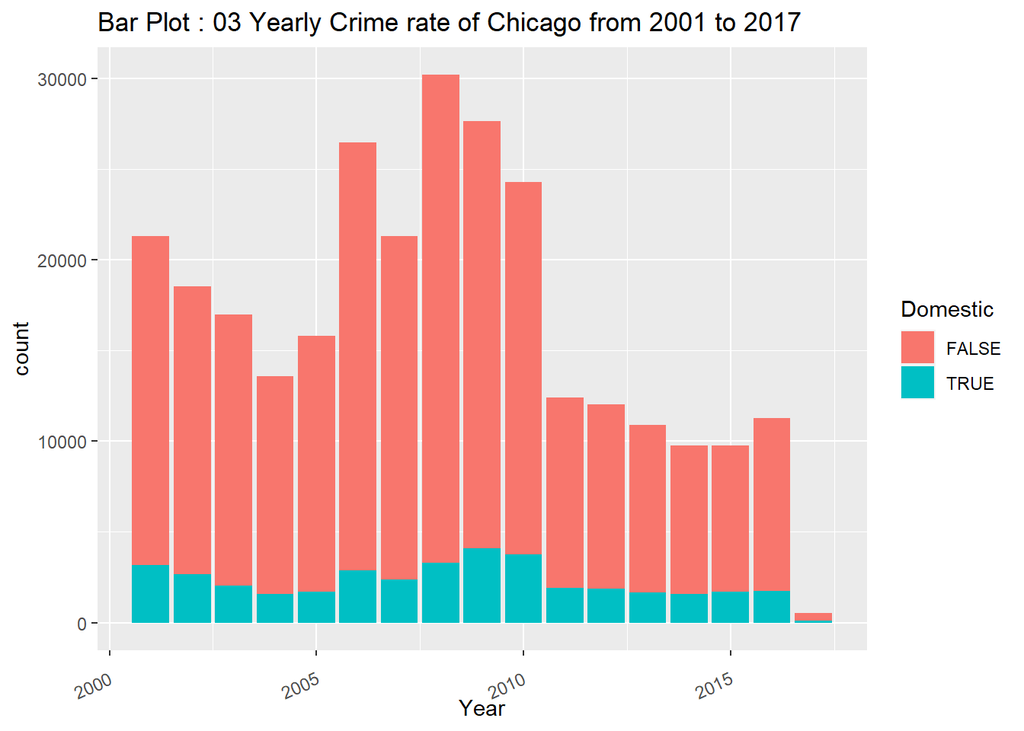

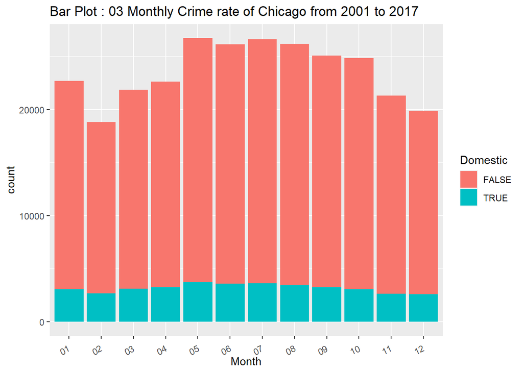

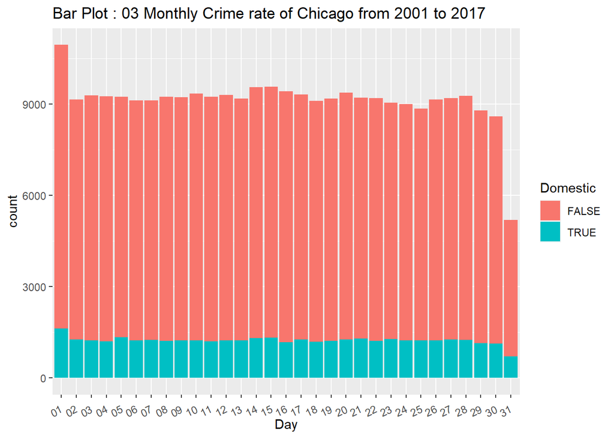

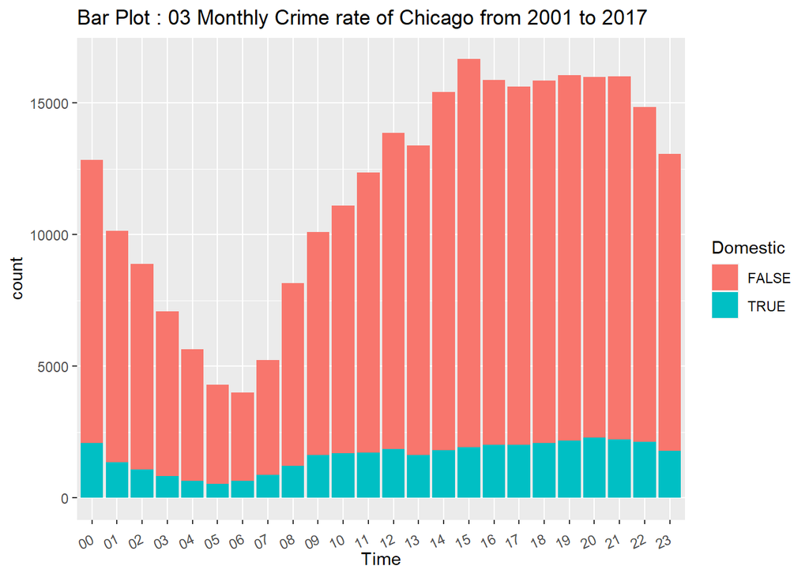

```r
ggplot(group_by_Year,aes(x=Year,y=count, fill= Domestic))+
  geom_bar(stat="identity")+
  theme(axis.text.x = element_text(angle = 25, vjust = 0.5, hjust=1))+
  ggtitle("Bar Plot : 03 Yearly Crime rate of Chicago from 2001 to 2017")


group_by_Month <- cleaned_dataset %>%
  group_by(Month,Domestic) %>%
  summarise(count = n()) %>%
  mutate(
    porportion = round(count/sum(count),2),
    percentage = round((count/sum(count)*100),2)
  ) %>%
  arrange((Month))
ggplot(group_by_Month,aes(x=Month,y=count, fill= Domestic))+
  geom_bar(stat="identity")+
  theme(axis.text.x = element_text(angle = 25, vjust = 0.5, hjust=1))+
  ggtitle("Bar Plot : 03 Monthly Crime rate of Chicago from 2001 to 2017")

group_by_Day <- cleaned_dataset %>%
  group_by(Day,Domestic) %>%
  summarise(count = n()) %>%
  mutate(
    porportion = round(count/sum(count),2),
    percentage = round((count/sum(count)*100),2)
  ) %>%
  arrange((Day))
ggplot(group_by_Day,aes(x=Day,y=count, fill= Domestic))+
  geom_bar(stat="identity")+
  theme(axis.text.x = element_text(angle = 25, vjust = 0.5, hjust=1))+
  ggtitle("Bar Plot : 03 Monthly Crime rate of Chicago from 2001 to 2017")

group_by_Time <- cleaned_dataset %>%
  group_by(Time,Domestic) %>%
  summarise(count = n()) %>%
  mutate(
    porportion = round(count/sum(count),2),
    percentage = round((count/sum(count)*100),2)
  ) %>%
  arrange((Time))
ggplot(group_by_Time,aes(x=Time,y=count, fill= Domestic))+
  geom_bar(stat="identity")+
  theme(axis.text.x = element_text(angle = 25, vjust = 0.5, hjust=1))+
  ggtitle("Bar Plot : 03 Monthly Crime rate of Chicago from 2001 to 2017")
```

### District Crime rate

```r
group_by_District <- cleaned_dataset %>%
  group_by(District,Domestic) %>%
  summarise(count = n()) %>%
  mutate(
    porportion = round(count/sum(count),2),
    percentage = round((count/sum(count)*100),2)
  )
```

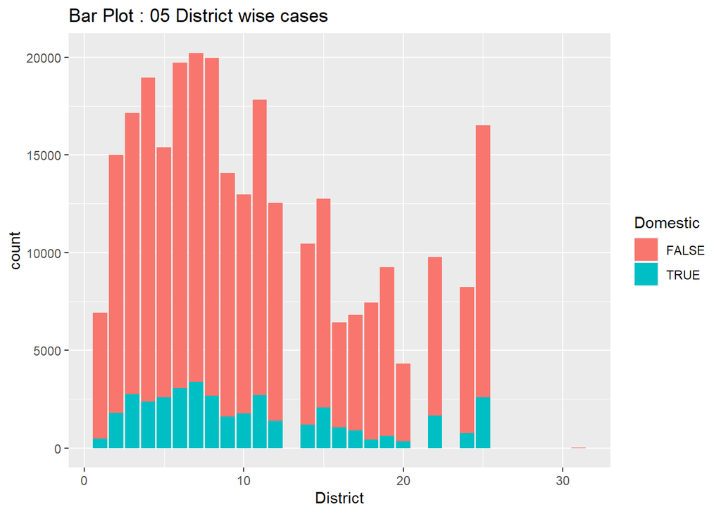

```r
ggplot(group_by_District,aes(x=District,y=count, fill= Domestic))+
  geom_bar(stat="identity")+
  ggtitle("Bar Plot : 05 District wise cases")+
  xlab("District")
```

## CHI-SQUARE ANALYSIS

H0 (null hypothesis) -> There is no relationship between District and Primary type of Crime H1 (Alternative Hypothesis) -> There is relationship between District and Primary type of Crime

```r
chi <- cleaned_dataset
myChisq <- xtabs(~ as.factor(Primary.Type) + as.factor(District), data = chi)

tidy(chisq.test(myChisq))%>%
  select(
    method,
    DF = parameter,
    p.value,
    statistic
  )%>%
  mutate(
    statistic = round(statistic,2)
  )
```

```
## # A tibble: 1 x 4
##   method                        DF p.value statistic
##   <chr>                      <int>   <dbl>     <dbl>
## 1 Pearson's Chi-squared test    66       0     2704.
```

Since the p.value is very significant, we will reject the null hypothesis.

## 2 WAY ANOVA TEST

Performing ANOVA test to examine if District varies by Primary type of crime and Arrests.

H0(null hypothesis) -> * Primary type of crime and Arrest has no effect on District. Also there is no interaction affect on District due to Primary type of crime and Arrests.

H1(Alternative Hypothesis) -> * Primary type of crime and Arrest has effect on District. Also there is interaction affect on District due to Primary type of crime and Arrests.

```r
two_way_fit <- aov(District ~as.factor(Primary.Type) * as.factor(Arrest) , data=cleaned_dataset)
tidy(two_way_fit)%>%
  mutate(
    sumsq = signif(sumsq, digits = 2),
    p.value = round(p.value,3),
    statistic = round(statistic,3)

  )
```

```
## # A tibble: 4 x 6
##   term                                      df    sumsq meansq statistic p.value
##   <chr>                                  <dbl>    <dbl>  <dbl>     <dbl>   <dbl>
## 1 as.factor(Primary.Type)                    3    11000 3.63e3     76.9        0
## 2 as.factor(Arrest)                          1    11000 1.13e4    240.         0
## 3 as.factor(Primary.Type):as.factor(Ar~      3     1400 4.53e2      9.60       0
## 4 Residuals                             282616 13000000 4.72e1     NA         NA
```

Interpretation : A two-way ANOVA was performed to analyze the effect of Primary type of crime and Arrest on District. A two-way ANOVA revealed that - Simple main effects analysis showed that Primary type of crime did have a statistically significant effect on District (p = 0).

## INTERACTION PLOT FROM ANOVA

```r
## merging Exterior values lesser than 60
test <- group_by_primary_type <- cleaned_dataset %>%
  group_by(Primary.Type,Domestic,District) %>%
  summarise(count = n())%>%
  mutate(
    porportion = round(count/sum(count),2),
    percentage = round((count/sum(count)*100),2)
  ) %>%
  arrange(desc(percentage))
```

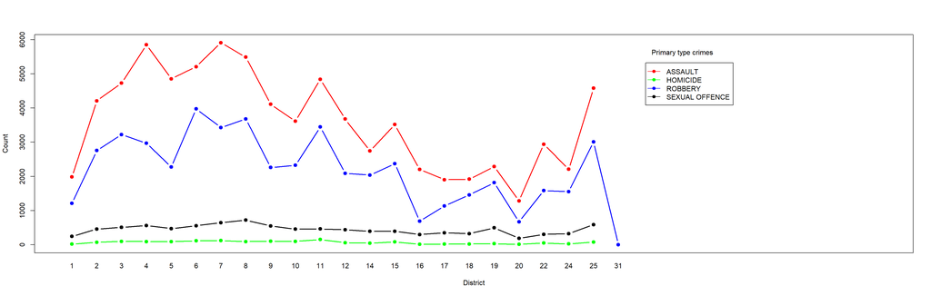

```r
interaction.plot(x.factor = test$District,
                 trace.factor = test$Primary.Type,
                 response = test$count,
                 fun = mean,
                 type = "b",
                 ylab = "Count",
                 xlab = "District",
                 col = c("red","green","blue","black"),
                 lty = 1, #line type
                 lwd = 2, #line width
                 trace.label = "Primary type crimes",
                 pch=c(19),             ### Symbols for levels of trace var.
                 fixed=TRUE,                    ### Order by factor order in data
                 leg.bty = "o")
```

## Spliting Dataset into train and test sets

Here we are going to sample our main dataset into 70-30 ratio as Train and test dataset respectively.

```r
set.seed(123)
trainIndex <- createDataPartition(cleaned_dataset$Arrest, p= 0.70, list = FALSE)
train <- cleaned_dataset[trainIndex,]
test <- cleaned_dataset[-trainIndex,]
```

## Linear Regression Model

Here we are going to check if crime rate has anything to do with the District, Arrest Made.

```r
Lm_train_dataset <- train %>%
  group_by(District, Arrest,Domestic) %>%
  summarise(count = n()) %>%
  mutate(
    Arrest = ifelse(Arrest == "TRUE",1,0),
    Domestic = ifelse(Domestic == "TRUE",1,0)
  )
Lm_test_dataset <- test %>%
  group_by(District, Arrest,Domestic) %>%
  summarise(count = n()) %>%
  mutate(
    Arrest = ifelse(Arrest == "TRUE",1,0),
    Domestic = ifelse(Domestic == "TRUE",1,0)
  )
```

### Linear Regression Summary of Train Dataset

```r
Model1 <- (lm(count ~ District * Arrest * Domestic , data = Lm_train_dataset))
summary(Model1)
```

```
##
## Call:
## lm(formula = count ~ District * Arrest * Domestic, data = Lm_train_dataset)
##
## Residuals:
##     Min      1Q  Median      3Q     Max
## -5019.3  -250.8   -38.5   250.0  3897.2
##
## Coefficients:
##                          Estimate Std. Error t value Pr(>|t|)
## (Intercept)               8560.87     474.51  18.042  < 2e-16 ***
## District                  -184.52      33.61  -5.491 4.48e-07 ***
## Arrest                   -6639.93     653.30 -10.164 4.05e-16 ***
## Domestic                 -7199.80     671.06 -10.729  < 2e-16 ***
## District:Arrest            144.74      44.69   3.239  0.00174 **
## District:Domestic          152.38      47.53   3.206  0.00193 **
## Arrest:Domestic           5604.27     936.55   5.984 5.66e-08 ***
## District:Arrest:Domestic  -119.42      65.23  -1.831  0.07083 .
## ---
## Signif. codes:  0 '***' 0.001 '**' 0.01 '*' 0.05 '.' 0.1 ' ' 1
##
## Residual standard error: 1125 on 81 degrees of freedom
##   (1 observation deleted due to missingness)
## Multiple R-squared:  0.8419, Adjusted R-squared:  0.8282
## F-statistic:  61.6 on 7 and 81 DF,  p-value: < 2.2e-16
```

From the above summary of the linear regression model for train dataset developed by us you can see that the R squared value is 0.84. that means our model is 84% fit for predicting the crime rate. The is not much difference in the R-square value and the Adjusted R-squared Value. Also the Pvalue is below the significant level (0.05) This model explains a lot of variation within data and is significant. Thus this model is best fit for Predicting the Crime rate of Chicago.

### Linear Regression Summary of Test Dataset

```r
Model2 <- (lm(count ~ District * Arrest* Domestic  , data = Lm_test_dataset))
summary(Model2)
```

```
##
## Call:
## lm(formula = count ~ District * Arrest * Domestic, data = Lm_test_dataset)
##
## Residuals:
##      Min       1Q   Median       3Q      Max
## -2129.49  -125.18   -15.99    95.65  1692.40
##
## Coefficients:
##                          Estimate Std. Error t value Pr(>|t|)
## (Intercept)               3654.66     203.45  17.964  < 2e-16 ***
## District                   -78.16      14.41  -5.425 6.02e-07 ***
## Arrest                   -2881.07     287.72 -10.014 9.09e-16 ***
## Domestic                 -3064.20     287.72 -10.650  < 2e-16 ***
## District:Arrest             66.23      20.38   3.250  0.00169 **
## District:Domestic           64.06      20.38   3.144  0.00234 **
## Arrest:Domestic           2427.67     406.89   5.966 6.30e-08 ***
## District:Arrest:Domestic   -54.80      28.82  -1.902  0.06080 .
## ---
## Signif. codes:  0 '***' 0.001 '**' 0.01 '*' 0.05 '.' 0.1 ' ' 1
##
## Residual standard error: 482.5 on 80 degrees of freedom
##   (1 observation deleted due to missingness)
## Multiple R-squared:  0.8417, Adjusted R-squared:  0.8278
## F-statistic: 60.76 on 7 and 80 DF,  p-value: < 2.2e-16
```

From the above summary of the linear regression model for test sample dataset developed by us you can see that the R squared value is 0.84. that means our model is 84% fit for predicting the crime rate. The is not much difference in the R-square value and the Adjusted R-squared Value. Also the P-value is below the significant level (0.05) This model explains a lot of variation within data and is significant. Thus this model is best fit for Predicting the Crime rate of Chicago.

### Residual Plotting of the models

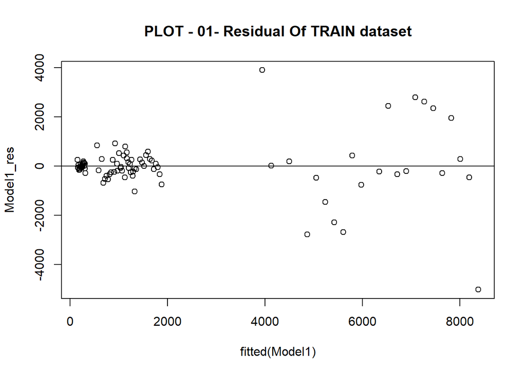

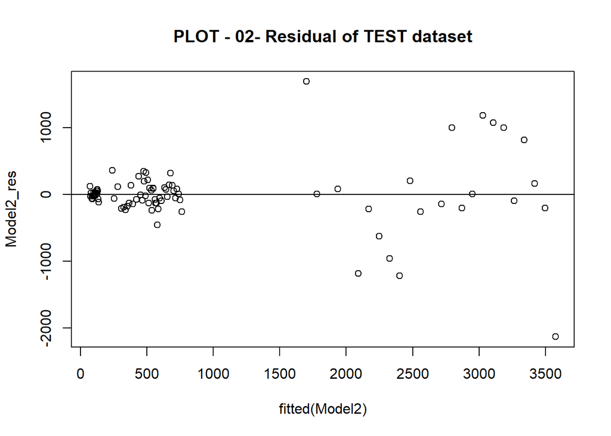

```r
Model1_res <- resid(Model1)
Model2_res <- resid(Model2)

plot(fitted(Model1), Model1_res) +
  abline(0,0)+
  title("PLOT - 01- Residual Of TRAIN dataset")

plot(fitted(Model2), Model2_res) +
  abline(0,0)+
  title("PLOT - 02- Residual of TEST dataset")
```

### Q-Q PLOT

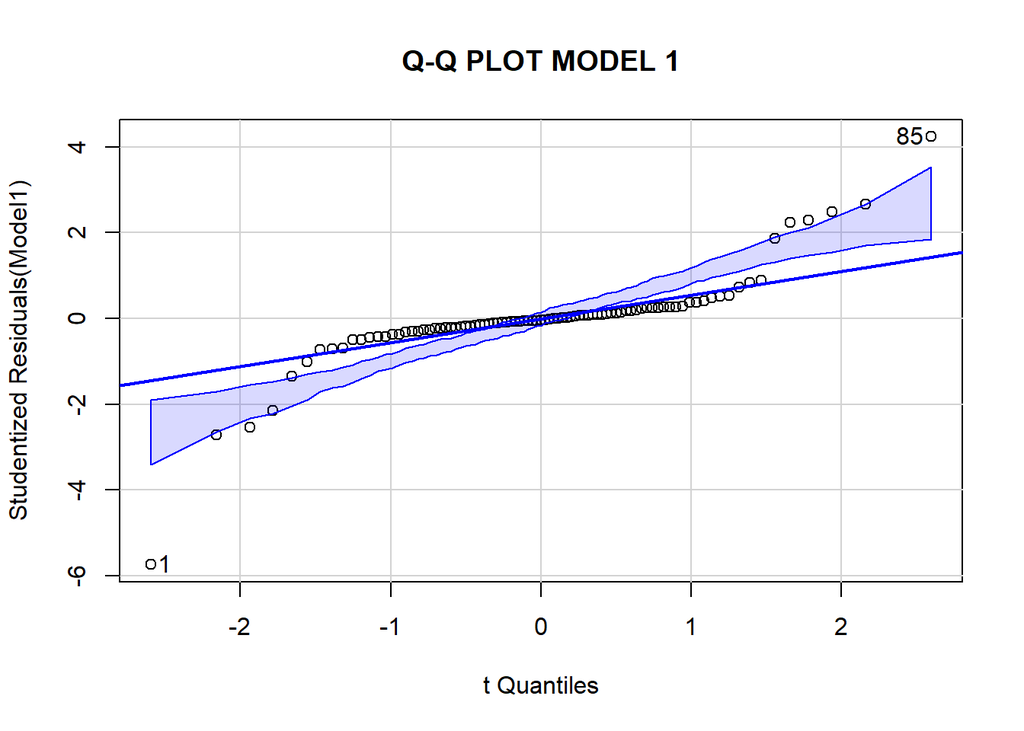

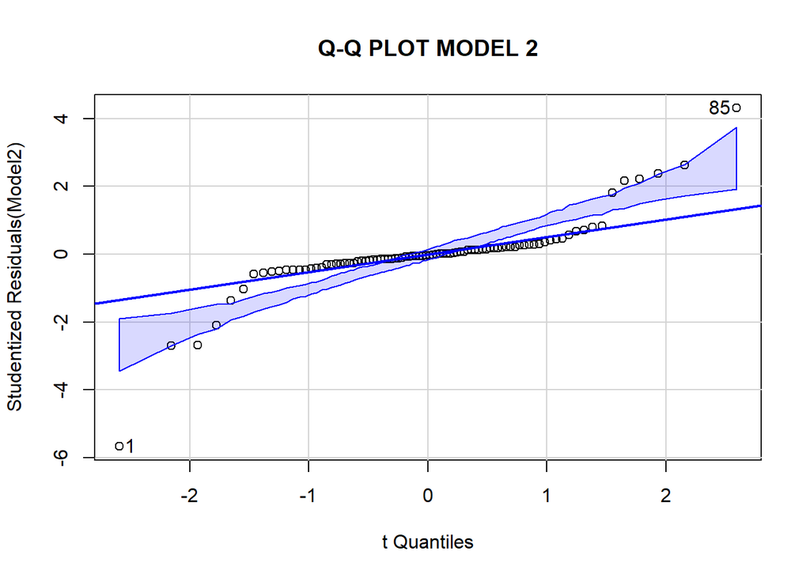

```r
qqPlot(Model1)+
  title("Q-Q PLOT MODEL 1")
qqPlot(Model2)+
  title("Q-Q PLOT MODEL 2")
```

### MULTI COLLINEARITY

```r
## model 1
vif(Model1)
```

```
                  District                   Arrest                 Domestic
                  4.312275                 7.498035                 7.911155
           District:Arrest        District:Domestic          Arrest:Domestic
                  9.651069                 9.888683                11.471286
  District:Arrest:Domestic
                 12.027058
```

```r
## model 2
vif(Model2)
```

```
                  District                   Arrest                 Domestic
                  4.000000                 7.823253                 7.823253
           District:Arrest        District:Domestic          Arrest:Domestic
                  9.823253                 9.823253                11.734879
  District:Arrest:Domestic
                 12.734879
```

Multicollinearity help us to know if the predictor variables (independent) have correlation or not. If the value is below 5 we can say that there is not correlation between the Predictor variables.

## Logistic Regression

```r
logistic_dataset_train <- train %>%
  group_by(Primary.Type,Domestic,Arrest,District) %>%
  summarise(count = n())%>%na.omit()
logistic_dataset_test <- train %>%
  group_by(Primary.Type,Domestic,Arrest,District) %>%
  summarise(count = n())%>%na.omit()
model3 <- glm(Arrest ~ .,data = logistic_dataset_train, family = "binomial")
summary(model3)
```

```
##
## Call:
## glm(formula = Arrest ~ ., family = "binomial", data = logistic_dataset_train)
##
## Deviance Residuals:
##     Min       1Q   Median       3Q      Max
## -2.0486  -1.0410   0.4571   0.8969   1.5806
##
## Coefficients:
##                              Estimate Std. Error z value Pr(>|z|)
## (Intercept)                 4.3960774  0.7632663   5.760 8.43e-09 ***
## Primary.TypeHOMICIDE       -3.0405565  0.6566574  -4.630 3.65e-06 ***
## Primary.TypeROBBERY        -2.1545051  0.5716443  -3.769 0.000164 ***
## Primary.TypeSEXUAL OFFENCE -2.9099295  0.5711848  -5.095 3.50e-07 ***
## DomesticTRUE               -1.4147543  0.3103906  -4.558 5.16e-06 ***
## District                   -0.0177081  0.0179516  -0.986 0.323917
## count                      -0.0035847  0.0006232  -5.753 8.79e-09 ***
## ---
## Signif. codes:  0 '***' 0.001 '**' 0.01 '*' 0.05 '.' 0.1 ' ' 1
##
## (Dispersion parameter for binomial family taken to be 1)
##
##     Null deviance: 465.03  on 335  degrees of freedom
## Residual deviance: 361.74  on 329  degrees of freedom
## AIC: 375.74
##
## Number of Fisher Scoring iterations: 7
```

```r
model4 <- glm(Arrest ~. ,data = logistic_dataset_test, family = "binomial")
summary(model4)
```

```
##
## Call:
## glm(formula = Arrest ~ ., family = "binomial", data = logistic_dataset_test)
##
## Deviance Residuals:
##     Min       1Q   Median       3Q      Max
## -2.0486  -1.0410   0.4571   0.8969   1.5806
##
## Coefficients:
##                              Estimate Std. Error z value Pr(>|z|)
## (Intercept)                 4.3960774  0.7632663   5.760 8.43e-09 ***
## Primary.TypeHOMICIDE       -3.0405565  0.6566574  -4.630 3.65e-06 ***
## Primary.TypeROBBERY        -2.1545051  0.5716443  -3.769 0.000164 ***
## Primary.TypeSEXUAL OFFENCE -2.9099295  0.5711848  -5.095 3.50e-07 ***
## DomesticTRUE               -1.4147543  0.3103906  -4.558 5.16e-06 ***
## District                   -0.0177081  0.0179516  -0.986 0.323917
## count                      -0.0035847  0.0006232  -5.753 8.79e-09 ***
## ---
## Signif. codes:  0 '***' 0.001 '**' 0.01 '*' 0.05 '.' 0.1 ' ' 1
##
## (Dispersion parameter for binomial family taken to be 1)
##
##     Null deviance: 465.03  on 335  degrees of freedom
## Residual deviance: 361.74  on 329  degrees of freedom
## AIC: 375.74
##
## Number of Fisher Scoring iterations: 7
```

```r
coef_Model1 <-stargazer(model3,odd.ratio = TRUE ,type = "text")
```

```
  ======================================================
                                 Dependent variable:
                             ---------------------------
                                       Arrest
  ------------------------------------------------------
  Primary.TypeHOMICIDE                -3.041***
                                       (0.657)

  Primary.TypeROBBERY                 -2.155***
                                       (0.572)

  Primary.TypeSEXUAL OFFENCE          -2.910***
                                       (0.571)

  Domestic                            -1.415***
                                       (0.310)

  District                             -0.018
                                       (0.018)

  count                               -0.004***
                                       (0.001)

  Constant                            4.396***
                                       (0.763)

  ------------------------------------------------------
  Observations                           336
  Log Likelihood                      -180.869
  Akaike Inf. Crit.                    375.739
  ======================================================
  Note:                      *p<0.1; **p<0.05; ***p<0.01

  ====
  TRUE
  ----
```

```r
coef_Model2 <-stargazer(model4,odd.ratio = TRUE ,type = "text")
```

```
  ======================================================
                                 Dependent variable:
                             ---------------------------
                                       Arrest
  ------------------------------------------------------
  Primary.TypeHOMICIDE                -3.041***
                                       (0.657)

  Primary.TypeROBBERY                 -2.155***
                                       (0.572)

  Primary.TypeSEXUAL OFFENCE          -2.910***
                                       (0.571)

  Domestic                            -1.415***
                                       (0.310)

  District                             -0.018
                                       (0.018)

  count                               -0.004***
                                       (0.001)

  Constant                            4.396***
                                       (0.763)

  ------------------------------------------------------
  Observations                           336
  Log Likelihood                      -180.869
  Akaike Inf. Crit.                    375.739
  ======================================================
  Note:                      *p<0.1; **p<0.05; ***p<0.01

  ====
  TRUE
  ----
```

### Effect Plots

The effect plots show us how predicted probabilities change when we change our independent variables.

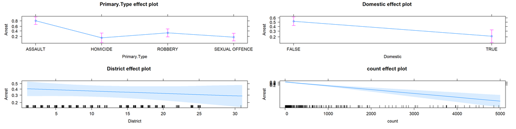

```r
plot(allEffects(model3))
```

From the above plotting we can see the effects in arrest been made based on Type of Crime, Domestic violence, Districts wise and counts.

- From 1st plot you can see that the arrest been made in cases like Violent is more than rest of the cases.
- From 2nd plot you can see that the arrest been made in cases When domestic violence is presence is less.
- From 3rd plot you can see that the arrest been made in cases When the district cases(from 1 to 10) is in decreasing trend.
- From 4th plot you can see that the arrest been made in cases When the cases increases the arrests made are decreasing.

reference :

- Multiple and Logistic Regression in R [DataCamp]
- StatQuest: Logistic Regression. (2018, March 5). YouTube. https://www.youtube.com/watch?v=yIYKR4sgzI8&list=PLblh5JKOoLUKxzEP5HA2d-Li7IJkHfXSe
- » Interpreting Residual Plots to Improve Your Regression. (2021, April 12). Qualtrics. https://www.qualtrics.com/support/stats-iq/analyses/regression-guides/interpreting-residual-plots-improve-regression/
- Residual plots | Exploring bivariate numerical data | AP Statistics | Khan Academy. (2017, July 12). YouTube. https://www.youtube.com/watch?v=VamMrPZ-8fc
- Z. (2021, April 22). How to Create a Residual Plot in R. Statology. https://www.statology.org/residual-plot-r/
- Visualizing two variables - Characterizing bivariate relationships. (n.d.). DataCamp. https://campus.datacamp.com/courses/correlation-and-regression-in-r/visualizing-two-variables?ex=4